# RcppMsgPack: MessagePack Headers and Interface Functions for R

#### Transferring large datasets from Python to R and back

To evaluate the performance of *MsgPack* serialization, we benchmarked the transfer of the MNIST (LeCun et al. 2010) and CIFAR-10 (Krizhevsky 2009) datasets to and from Python and *R*. We compared this approach to writing and reading in CSV format, and to writing and reading using [*feather*](https://CRAN.R-project.org/package=feather) (Wickham et al. 2016), a cross-platform library and specification for efficiently handling tabular data. (The *feather* package is no longer actively developed, and will be superseded by Apache Arrow (Apache Arrow Developers 2018), a more general cross-language development platform for working with in-memory data in a standardized language-independent columnar memory format. However, Arrow is not yet available for R.) In Python, serialization of the data was performed using the *msgpack* package and written to disk in binary format:

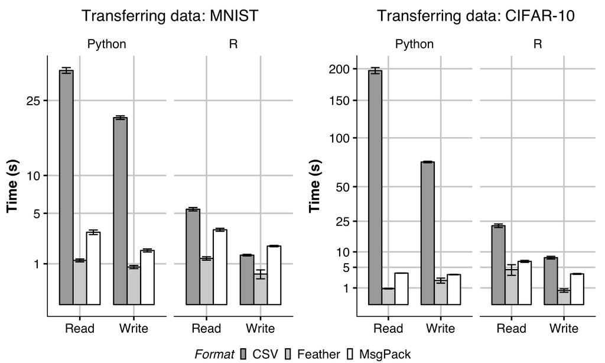

Figure 2: Transferring the MNIST dataset (left) and the CIFAR-10 dataset (right) to and from *R* and Python using either *MsgPack*, *feather* or CSV format.

```r
  xb = msgpack.packb(x)
  with open("/tmp/dataset.mp", "wb") as file:
      file.write(xb)
```

Conversely, the `unpackb` function was used when benchmarking the transfer time from *R* to Python:

```r
  with open("/tmp/dataset.mp", "rb") as file:
      file.write(xb)
  x = msgpack.unpackb(file.read())
```

In *R*, we used the `readBin` function followed by `msgpack_unpack` function to deserialize the dataset. Alternatively, one could use the helper function `msgpack_read`.

```r
  xb <- readBin(con = "/tmp/dataset.mp", "raw",
                n=file.info("/tmp/dataset.mp")$size)
  x <- msgpack_unpack(xb, simplify=T)
```

Subsequently, the data can be re-serialized and written to disk using the `msgpack_pack` function followed by `writeBin`:

```r
  xb <- msgpack_pack(x)
  writeBin(xb,"/tmp/dataset.mp", useBytes=T)
```

For CSV format, we used the `fread` and `fwrite` functions in the [*data.table*](https://CRAN.R-project.org/package=data.table) package (Dowle et al. 2018) to write and read CSV tables in *R*. In Python, we used the package *numpy* `savetxt` and `loadtxt` functions (Walt et al. 2011). For the *feather* format, we used the `write_feather` and `read_feather` functions within the *feather* package in *R* and Python. All approaches were benchmarked after clearing the system cache and replicated 5 times (Figure 2).

Serialization and de-serialization of objects from *MsgPack* objects was similar between *R* and Python, with a slight speed advantage going to Python. Reading *MsgPack* objects was generally considerably faster than reading CSV format in both *R* and Python. Comparing *MsgPack* to *feather*, *feather* was generally faster. As *feather* is designed for columnar binary data, it does not use a header for every element and therefore has an advantage over the (more general) *MsgPack* in this context.

One surprising result is in writing of CSVs in R. Using *data.table*, writing the MNIST dataset was faster than *MsgPack*, although not quite as fast as *feather*. The MNIST dataset is formatted as a single floating point value in per pixel by *TensorFlow* (Abadi et al. 2016). When writing floating point data as CSV, both *numpy* and the *data.table* package truncate floating point numbers by default, which causes loss of precision.

#### MsgPack serialization memory usage

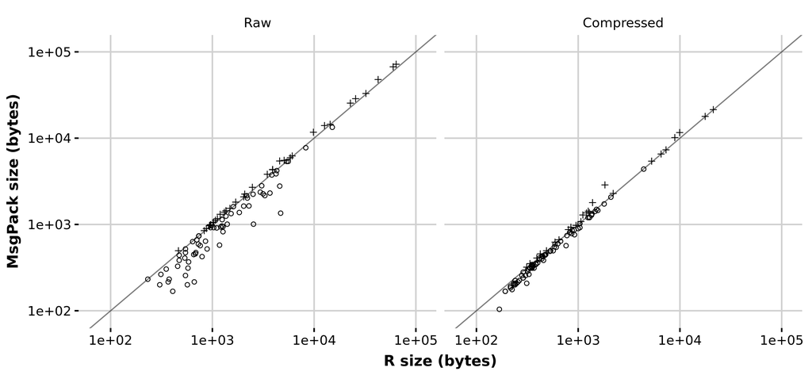

Figure 3: Serialization memory usage: *MsgPack* vs. *R*. Left: raw serialization size for datasets in *datasets*. Right: Gzip-compressed serialization size.

To compare the memory usage of *MsgPack* to native *R* serialization, we serialized the datasets found in the `datasets` *R* package (Figure 3). For *R* serialization, this was done by calling the `serialize` function for native *R* serialization or calling the `msgpack_pack` function for *MsgPack* serialization. For compression, the `memCompress` function was called on the results. Some datasets contained formulas, or other *R*-specific attributes that can’t be stored in *MsgPack*; these attributes were removed prior to serialization and compression.

Memory usage was generally very similar between *MsgPack* and native *R*. Although there were some differences in raw serialization, the difference seems to be less apparent after compression. For some uncompressed serializations, *MsgPack* significantly outperformed *R* in memory usage. This is attributable to efficient integer storage: *MsgPack* stores variable size integers depending on the integer magnitude, and can be as low as 8 bits. Native *R* serialization uses the modified External Data Representation (XDR) standard (Srinivasan 1995), which uses a fixed 32 bits for integers. Furthermore, attributes of each dataset are stored as lists internally, which can increase the relative overhead for small datasets, as *R* lists are not memory-efficient objects.

On the other hand, every *MsgPack* element has a short header of several bits, which increases its memory overhead, particularly for large vectors. This overhead is apparent for larger datasets, where *R* typically is more memory efficient.

#### Serialization of large lists

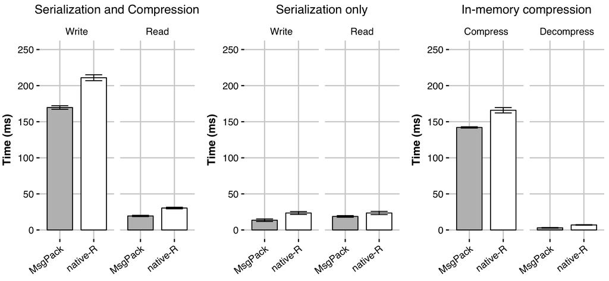

Figure 4: Serialization and compression time of a large list of DNA sequences.

As mentioned, one situation where *MsgPack* serialization is much more efficient than *R* serialization is how it handles list objects. Because R lists have a large memory overhead, both compression times and writing/reading to disk are faster using the *MsgPack* format. To show this, we generated a contrived list of DNA sequences as follows:

```r
  x <- replicate(10000, {
      replicate(sample(5,1), {
          paste(sample(c("G","C","A","T"), size=sample(50,1), replace=T), collapse="")
      })
  })
```

If the data structure of the object is known, using the C++ headers directly can speed up serialization and de-serialization by avoiding the logic involved in serializing generic data structures, although the speed-up is not large. Compression and writing to disk can also be performed directly within C++, for example, by using the zlib C++ library (Gailly and Adler 2018) to perform standard DEFLATE compression. The example below illustrates *MsgPack* serialization and subsequent compression using the *zlib* library:

```r
  void list_pack_gzip(List x, std::string file) {
    std::stringstream buffer;
    msgpack::packer<std::stringstream> pk(&buffer);
    pk.pack_array(x.size());
    for(int i=0; i<x.size(); i++) {
      CharacterVector xi = x[i];
      if(xi.size() == 1) {
        pk.pack(Rcpp::as<std::string>(xi[0]));
      } else {
        pk.pack_array(xi.size());
        for(int j=0; j<xi.size(); j++) {
          pk.pack(Rcpp::as<std::string>(xi[j]));
        }
      }
    }
    std::string bufstr = buffer.str();
    gzFile fi = gzopen(file.c_str(),"wb");
    gzwrite(fi, bufstr.c_str(), bufstr.size());
    gzclose(fi);
  }
```

Conversely, uncompression and deserialization would need to be performed to recover the original R object. The following C++ function illustrates how this could be done:

```r
  Rcpp::List list_unpack_gzip(std::string file) {
    gzFile fi = gzopen(file.c_str(),"rb");
    char buf[8192];
    std::vector<char> dat;
    uint b = gzread(fi, buf, 8192);
    while (b) {
      dat.insert(dat.end(), buf, buf + b);
      b = gzread(fi, buf, 8192);
    }
    gzclose(fi);
    std::string message = std::string(dat.data(), dat.size());
    msgpack::object_handle oh;
    msgpack::unpack(oh, message.data(), message.size());
    msgpack::object obj = oh.get();
    std::vector<msgpack::object> obj_vector;
    obj.convert(obj_vector);
    Rcpp::List L = Rcpp::List(obj_vector.size());
    std::vector< std::string > temp_str_vec;
    std::string temp_str;
    for (int i=0; i< obj_vector.size(); i++) {
      if (obj_vector[i].type == msgpack::type::ARRAY) {
        obj_vector[i].convert(temp_str_vec);
        L[i] = Rcpp::wrap(temp_str_vec);
      } else {
        obj_vector[i].convert(temp_str);
        L[i] = Rcpp::wrap(temp_str);
      }
    }
    return(L);
  }
```

To illustrate the potential benefit of this approach, we compared *MsgPack* serialization and *zlib* compression to standard R serialization using the `saveRDS` function (Figure 4). Using *MsgPack*, serialization is slightly faster for the example above. The timing of these two approaches can be broken down by process: both serialization and compression to disk (and vice versa) are faster using the *MsgPack* approach described above for certain types of data structures, such as lists. However, for most other types of data structures, native R serialization is usually faster. Most of the time-saving comes from the fact that the serialized *MsgPack* message is considerably smaller, leading to faster compresion time and/or faster reading and writing to disk.

### 3 Summary

The examples given above show how working with the R interface functions the C++ headers in *RcppMsgPack* can be useful in transferring data and integrated within data analysis workflows. The package allows fast and flexible serialization of generic data structures in R, and equivalent de-serialization of objects from other langauages. The *RcppMsgPack* package is hosted on CRAN, and can be installed via the standard `install.packages("RcppMsgPack")` command.

### 4 Supplementary materials

Supplementary materials are available in addition to this article. It can be downloaded at RJ-2018-068.zip

### 5 CRAN packages used

mongolite, RProtoBuf, RcppRedis, RcppMsgPack, Rcpp, nanotime, httr, feather, data.table

### 6 CRAN Task Views implied by cited packages

ChemPhys, Databases, Finance, HighPerformanceComputing, NumericalMathematics, TimeSeries, WebTechnologies

M. Abadi, P. Barham, J. Chen, Z. Chen, A. Davis, J. Dean, M. Devin, S. Ghemawat, G. Irving, M. Isard, et al. TensorFlow: A system for large-scale machine learning. In *OSDI*, pages. 265–283 2016.

Apache Arrow Developers. Apache Arrow: A cross-language development platform for in-memory data. 2018.

T. Ching, D. Eddelbuettel, the authors and ontributors of MsgPack. *RcppMsgPack: ’MsgPack’ c++ header files and interface functions for r.* 2018. URL https://cran.r-project.org/package=RcppMsgPack. R package version 0.2.3.

T. Dawborn and J. R. Curran. Docrep: A lightweight and efficient document representation framework. In *Proceedings of COLING 2014, the 25th international conference on computational linguistics: Technical papers*, pages. 762–771 2014.

M. Dowle, A. Srinivasan, J. Gorecki, M. Chirico, P. Stetsenko, T. Short, S. Lianoglou, E. Antonyan, M. Bonsch and H. Parsonage. *data.table: Extension of ’data.frame’.* 2018. URL https://cran.r-project.org/package=data.table. R package version 1.11.8.

D. Eddelbuettel. *RcppRedis: Rcpp bindings for redis using the hiredis library.* 2018. URL https://cran.r-project.org/package=RcppRedis. R package version 0.1.9.

D. Eddelbuettel. *Seamless R and C++ integration with Rcpp.* New York: Springer-Verlag, 2013. ISBN 978-1-4614-6867-7.

D. Eddelbuettel, R. François, J. Allaire, K. Ushey, Q. Kou, N. Russel, J. Chambers and D. Bates. *Rcpp: Seamless R and C++ integration.* 2018. URL https://cran.r-project.org/package=Rcpp. R package version 1.0.0.

D. Eddelbuettel and L. Silvestri. *Nanotime: Nanosecond-resolution time for r.* 2018. URL https://cran.r-project.org/package=nanotime. R package version 0.2.3.

D. Eddelbuettel, M. Stokely and J. Ooms. RProtoBuf: Efficient cross-language data serialization in R. *Journal of Statistical Software*, 71(2): 1–24, 2016. URL https://doi.org/10.18637/jss.v071.i02.

S. Furuhashi. MessagePack. 2018.

J.-L. Gailly and M. Adler. Zlib compression library. 2018. URL https://zlib.net/.

Google. Protocol Buffers. 2018.

S. T.-B. Hamida, E. B. Hamida and B. Ahmed. A new mHealth communication framework for use in wearable WBANs and mobile technologies. *Sensors*, 15(2): 3379–3408, 2015.

IEEE Standards Committee. 754-2008 IEEE standard for floating-point arithmetic. *IEEE Computer Society Std*, 2008: 2008.

A. Krizhevsky. Learning multiple layers of features from tiny images. University of Toronto. 2009.

Y. LeCun, C. Cortes and C. Burges. MNIST handwritten digit database. *AT&T Labs [Online]. Available: http://yann. lecun. com/exdb/mnist*, 2: 2010.

MongoDB. BSON (binary JSON) serialization. 2018.

J. Ooms. The jsonlite package: A practical and consistent mapping between JSON data and r objects. *arXiv:1403.2805 [stat.CO]*, 2014. URL http://arxiv.org/abs/1403.2805.

R. Srinivasan. *XDR: External data representation standard. No. RFC 1832.* 1995. URL http://www.rfc-editor.org/rfc/pdfrfc/rfc1832.txt.pdf.

S. van der Walt, S. C. Colbert and G. Varoquaux. The NumPy array: A structure for efficient numerical computation. *Computing in Science & Engineering*, 13(2): 22–30, 2011.

H. Wickham. *Httr: Tools for working with URLs and HTTP.* 2018. URL https://cran.r-project.org/package=httr. R package version 1.4.0.

H. Wickham, RStudio, Feather developers, Google and LevelDB Authors. *Feather: R bindings to the feather API.* 2016. URL https://cran.r-project.org/package=feather. R package version 0.3.1.